# Data Exploration with R

Kamil Kozera

2023-11-16

# Introduction

Bellabeat, founded by Urška Sršen and Sando Mur, pioneers high-tech health-focused smart products. Using beautifully designed technology, Bellabeat empowers women worldwide with insights on activity, sleep, stress, and reproductive health. Established in 2013, the company rapidly expanded globally, offering a range of products through online retailers and their own e-commerce platform. Bellabeat employs a strategic mix of traditional and digital marketing, including Google Search, social media, YouTube, and the Google Display Network. Sršen seeks to leverage consumer data analysis to enhance product usage insights and inform future marketing strategies. Urška believes that analyzing smart device fitness data can unlock new opportunities. My task is to analyze smart device data, and derive insights into consumer usage patterns. These insights will shape the company’s marketing strategy. My findings and high-level recommendations will be presented to the Bellabeat executive team.

### Bellabeat products

- **Bellabeat App**: An application providing comprehensive health data, including activity, sleep, stress, menstrual cycle, and mindfulness habits. It aids users in understanding their habits and making healthier decisions. The app connects to Bellabeat’s smart wellness products.
- **Leaf**: A versatile wellness tracker wearable as a bracelet, necklace, or clip. It links to the Bellabeat app, monitoring activity, sleep, and stress for a holistic health overview.
- **Time**: A wellness watch blending classic aesthetics with smart technology, tracking activity, sleep, and stress. The Time watch connects to the Bellabeat app, offering insights into daily wellness routines.
- **Spring**: A smart water bottle ensuring proper hydration by tracking daily water intake. The Spring bottle links to the Bellabeat app, monitoring hydration levels throughout the day.
- **Bellabeat** Membership: A subscription-based program granting users 24/7 access to personalized guidance on nutrition, activity, sleep, health, beauty, and mindfulness. Tailored to individual lifestyles and goals, this membership provides holistic support for overall well-being.

# Understanding the market

The [FitBit](https://www.kaggle.com/datasets/arashnic/fitbit) dataset provided by the stakeholder is a bit outdated because the data is from 2016, meaning a lot has changed, partly due to the pandemic. During my research, I found out that many people bought smartwatches or other wellness wearables simply because they were worried about their health. Additionally, the smart wearables market is emerging and very dynamic. I decided to obtain additional data to assist me further.

[figure not shown]

- India’s wearable band market is booming, having exceptional triple-digit growth in Q1 2023, local vendors such as Fire Boltt, Noise and boAt are propelling the market forward with value-for-money focused strategies, capturing rising demand for basic watches. However, relying solely on entry-level hardware will be insufficient to sustain strong volumes in the long term. To create upgrade opportunities, vendors must adapt to changing consumer demands for improved features and integrated device experiences.Indian market might be a good choice for marketing purposes for Bellabeat.

[figure not shown]

# Data Cleaning

This dataset was collected from 30 Fitbit users who willingly shared their fitness data through an online survey on Amazon Mechanical Turk between March 12 and May 12, 2016. The dataset includes daily activity (calories, intensities, and steps), heart rate, METs, sleep, and weight. The variations in the data reflect the use of different Fitbit trackers and individual tracking habits, making it a valuable resource for understanding diverse fitness behaviors.

## Importing the data

I need to load specific libraries before I can study the data. These will help me understand the information better and find important details.

```r
# Load tidyverse: Collection of packages for data manipulation and visualization.
library(tidyverse)

# Load ggcorrplot: Creates correlation plots using ggplot2 for data visualization.
library(ggcorrplot)

# Load gridExtra: Enables arrangement of multiple grid-based figures on one page.
library(gridExtra)
```

Instead of reading the files separately (18 in total), I’ll gather a list of file paths using ‘list.files()’ Then, using the ‘lapply()’ method, I’ll apply the ‘read_csv()’ function to each item in the list. After that, I’ll rename the datasets by removing the ‘_merged.csv’ part of the file name with ‘gsub()’ to make them simpler to handle.

```r
# Get a list of file names in the specified directory.
flist <- list.files("C:/bellabeats")

# Read each CSV file in the list and store them in a list of datasets.
datasets <- lapply(flist, read_csv)

# Extract base names from file paths and remove "_merged.csv" part, then set them as names for the datasets list.
names(datasets) <- gsub("_merged\\.csv", "", basename(flist))
```

## Examining the data

In the datasets analyzed, information is categorized by day, hour, minute, and second.

- Daily data includes steps, calories, and intensity levels (sedentary, light, moderate, very active), along with sleep duration, weight, and BMI.
- Hourly data offers insights into calories, intensity, and steps.
- Minute-level data covers calories, intensity levels, and steps in both narrow and wide formats. Additionally, minute data includes sleep duration and METs (used to estimate calorie expenditure for fitness monitoring).
- The seconds dataset offers heart rate information with second-by-second precision.

I’ll explore the datasets using the ‘data.frame()’ function, which combines vectors into a data frame. Additionally, ‘sapply()’ will apply functions to each dataset in the list.

```r
# Create a summary data frame with information about the datasets.
summary <- data.frame(
  "Rows" = sapply(datasets, function(x) nrow(x)),
  "Columns" = sapply(datasets, function(x) ncol(x)),
  "Unique_id" = sapply(datasets, function(x) n_distinct(x[[1]])),
  "Duplicated" = sapply(datasets, function(x) sum(duplicated(x))),
  "Missing_values" = sapply(datasets, function(x) sum(is.na(x)))
)

summary
```

```
##                            Rows Columns Unique_id Duplicated Missing_values
## dailyActivity               940      15        33          0              0
## dailyCalories               940       3        33          0              0
## dailyIntensities            940      10        33          0              0
## dailySteps                  940       3        33          0              0
## heartrate_seconds       2483658       3        14          0              0
## hourlyCalories            22099       3        33          0              0
## hourlyIntensities         22099       4        33          0              0
## hourlySteps               22099       3        33          0              0
## minuteCaloriesNarrow    1325580       3        33          0              0
## minuteCaloriesWide        21645      62        33          0              0
## minuteIntensitiesNarrow 1325580       3        33          0              0
## minuteIntensitiesWide     21645      62        33          0              0
## minuteMETsNarrow        1325580       3        33          0              0
## minuteSleep              188521       4        24        543              0
## minuteStepsNarrow       1325580       3        33          0              0
## minuteStepsWide           21645      62        33          0              0
## sleepDay                    413       5        24          3              0
## weightLogInfo                67       8         8          0             65
```

The dataset contains a variety of rows and columns. ‘heartrate_seconds’ and ‘weightLogInfo’ have fewer unique observations. About 77.7% of the data relates to 33 unique IDs. ‘minuteSleep’ and ‘sleepDay’ have 24 unique IDs, ‘heartrate_seconds’ have 14, and ‘weightLogInfo’ have 8. There are 543 duplicated rows in ‘minuteSleep’ and 3 in ‘sleepDay’. ‘weightLogInfo’ is the only dataset with missing values, all found in the ‘Fat’ column. Therefore, I will exclude this column from my analysis.

```r
# Calculate the number of missing values in the 'weightLogInfo' dataset for each column.
sapply(datasets$weightLogInfo,function(x) sum(is.na(x)))
```

```
##             Id           Date       WeightKg   WeightPounds            Fat
##              0              0              0              0             65
##            BMI IsManualReport          LogId
##              0              0              0
```

### Daily datasets

The daily datasets were cleaned up by removing the time component and renaming the date column, unnecessary columns were dropped, duplicate entries were removed, and a new column called ‘TotalMinutesNotAsleep’ was created. This column indicates the time spent restless or awake while in bed.

```r
# Process the 'dailyActivity' dataset: rename columns, remove unnecessary columns.
datasets$dailyActivity <- datasets$dailyActivity %>%
    rename(Date = ActivityDate) %>%
    select(-c(TrackerDistance, LoggedActivitiesDistance)) #

# Process the 'sleepDay' dataset: separate column, calculate additional column, remove unnecessary columns, keep distinct rows.
datasets$sleepDay <- datasets$sleepDay %>%
    separate(SleepDay, c("Date", "Time"), sep = " ") %>%
    mutate(TotalMinutesNotAsleep = TotalTimeInBed - TotalMinutesAsleep) %>%
    select(-c(TotalSleepRecords, TotalTimeInBed, Time)) %>%
    distinct()

# Process the 'weightLogInfo' dataset: separate columns, remove specified columns.
datasets$weightLogInfo <- datasets$weightLogInfo %>%
    separate(Date, c("Date", "Time"), sep = " ") %>%
    select(-c(WeightKg, Fat, IsManualReport, LogId, Time))
```

Then the daily datasets were combined via a full join using ‘Id’ and ‘Date’ as the keys.

```r
# Merge the 'dailyActivity', 'sleepDay', and 'weightLogInfo' datasets using full join on 'Id' and 'Date' columns.
daily <- datasets$dailyActivity %>%
    full_join(datasets$sleepDay, by = c("Id", "Date")) %>%
    full_join(datasets$weightLogInfo, by = c("Id", "Date"))
```

The ‘Date’ column was formatted correctly using ‘mdy()’, and a new column ‘Weekday’ was added for day-to-day analysis. Integer data was converted to numeric, and the ‘Id’ column was changed to a character type.

```r
# Convert 'Date' column to Date format using mdy() function from lubridate package.
daily$Date <- mdy(daily$Date)

# Add a new column 'Weekday' indicating the day of the week.
daily <- mutate(daily,
               Weekday =  wday(daily$Date,
                               label = TRUE,
                               abbr = FALSE,
                               week_start = getOption("lubridate.week.start", 1)),
                               .after = Date)

# Convert integer columns to numeric in the 'daily' dataset.
daily <- mutate_if(daily, is.integer, as.numeric)

# Convert 'Id' column to character type.
daily$Id <- as.character(daily$Id)
```

| Id | Date | Weekday | TotalSteps | TotalDistance | VeryActiveDistance | ModeratelyActiveDistance | LightActiveDistance | SedentaryActiveDistance | VeryActiveMinutes | FairlyActiveMinutes | LightlyActiveMinutes | SedentaryMinutes | Calories | TotalMinutesAsleep | TotalMinutesNotAsleep | WeightPounds | BMI |
| --- | --- | --- | --- | --- | --- | --- | --- | --- | --- | --- | --- | --- | --- | --- | --- | --- | --- |
| 1503960366 | 2016-04-12 | Tuesday | 13162 | 8.50 | 1.88 | 0.55 | 6.06 | 0 | 25 | 13 | 328 | 728 | 1985 | 327 | 19 | NA | NA |
| 1503960366 | 2016-04-13 | Wednesday | 10735 | 6.97 | 1.57 | 0.69 | 4.71 | 0 | 21 | 19 | 217 | 776 | 1797 | 384 | 23 | NA | NA |
| 1503960366 | 2016-04-14 | Thursday | 10460 | 6.74 | 2.44 | 0.40 | 3.91 | 0 | 30 | 11 | 181 | 1218 | 1776 | NA | NA | NA | NA |
| 1503960366 | 2016-04-15 | Friday | 9762 | 6.28 | 2.14 | 1.26 | 2.83 | 0 | 29 | 34 | 209 | 726 | 1745 | 412 | 30 | NA | NA |
| 1503960366 | 2016-04-16 | Saturday | 12669 | 8.16 | 2.71 | 0.41 | 5.04 | 0 | 36 | 10 | 221 | 773 | 1863 | 340 | 27 | NA | NA |
| 1503960366 | 2016-04-17 | Sunday | 9705 | 6.48 | 3.19 | 0.78 | 2.51 | 0 | 38 | 20 | 164 | 539 | 1728 | 700 | 12 | NA | NA |

### Long Data

To create meaningful visualizations, the data needed to be transformed into long format. A subset of data was extracted from the ‘daily’ dataset, including ‘Id’, ‘Date’, ‘Weekday’, ‘TotalMinutesAsleep,’ and ‘TotalMinutesNotAsleep.’ The ‘complete.cases()’ function was applied to retain only complete records. Subsequently, ‘TotalMinutesAsleep’ and ‘TotalMinutesNotAsleep’ were renamed to ‘Asleep’ and ‘NotAsleep’ for clarity. Finally, the ‘gather’ function was used to convert the data from wide to long format.

```r
sleep_long <- daily[, c(1:3, 15:16)] %>%
  filter(complete.cases(.)) %>%
  rename(Asleep = TotalMinutesAsleep,
         NotAsleep = TotalMinutesNotAsleep) %>%
  gather(key = "ActivityType",
         value = "Minutes",
         Asleep, NotAsleep)

head(sleep_long)
```

```
## # A tibble: 6 × 5
##   Id         Date       Weekday   ActivityType Minutes
##   <chr>      <date>     <ord>     <chr>          <dbl>
## 1 1503960366 2016-04-12 Tuesday   Asleep           327
## 2 1503960366 2016-04-13 Wednesday Asleep           384
## 3 1503960366 2016-04-15 Friday    Asleep           412
## 4 1503960366 2016-04-16 Saturday  Asleep           340
## 5 1503960366 2016-04-17 Sunday    Asleep           700
## 6 1503960366 2016-04-19 Tuesday   Asleep           304
```

To transform intensity data into long format, minutes and distances were initially converted separately. These transformed datasets were later merged with ‘inner_join()’, resulting in the final long format representation with columns labeled ‘Distance’ and ‘Minutes’.

```r
distance_long <- daily[, c(1:3, 6:9)] %>%
  rename(LightlyActiveDistance = LightActiveDistance) %>%
  gather(key = "ActivityType",
         value = "Distance",
         factor_key = TRUE,
         VeryActiveDistance, ModeratelyActiveDistance,
         LightlyActiveDistance, SedentaryActiveDistance) %>%
  mutate(ActivityType = gsub("Distance", "", ActivityType))

minutes_long <- daily[, c(1:3, 10:13)] %>%
  rename(ModeratelyActiveMinutes = FairlyActiveMinutes,
         SedentaryActiveMinutes = SedentaryMinutes) %>%
  gather(key = "ActivityType",
         value = "Minutes",
         factor_key = TRUE,
         VeryActiveMinutes, ModeratelyActiveMinutes,
         LightlyActiveMinutes, SedentaryActiveMinutes) %>%
  mutate(ActivityType = gsub("Minutes", "", ActivityType))

intensities_long <- inner_join(distance_long, minutes_long,
                               by = c("Id", "Date", "Weekday","ActivityType"))

head(intensities_long)
```

```
## # A tibble: 6 × 6
##   Id         Date       Weekday   ActivityType Distance Minutes
##   <chr>      <date>     <ord>     <chr>           <dbl>   <dbl>
## 1 1503960366 2016-04-12 Tuesday   VeryActive       1.88      25
## 2 1503960366 2016-04-13 Wednesday VeryActive       1.57      21
## 3 1503960366 2016-04-14 Thursday  VeryActive       2.44      30
## 4 1503960366 2016-04-15 Friday    VeryActive       2.14      29
## 5 1503960366 2016-04-16 Saturday  VeryActive       2.71      36
## 6 1503960366 2016-04-17 Sunday    VeryActive       3.19      38
```

To analyze daily minutes spent on different activity types (Very, Moderately, Lightly, Sedentary, Asleep, NotAsleep), two datasets, ‘sleep_long’ and ‘intensities_long,’ were merged. Since the column names were identical, a simple merging process sufficed. The data was then organized after the merge.

```r
activity_long <- sleep_long %>%
  full_join(intensities_long[, c(1:4, 6)], by = colnames(sleep_long)) %>%
  arrange(Id, Date)

head(activity_long)
```

```
## # A tibble: 6 × 5
##   Id         Date       Weekday ActivityType     Minutes
##   <chr>      <date>     <ord>   <chr>              <dbl>
## 1 1503960366 2016-04-12 Tuesday Asleep               327
## 2 1503960366 2016-04-12 Tuesday NotAsleep             19
## 3 1503960366 2016-04-12 Tuesday VeryActive            25
## 4 1503960366 2016-04-12 Tuesday ModeratelyActive      13
## 5 1503960366 2016-04-12 Tuesday LightlyActive        328
## 6 1503960366 2016-04-12 Tuesday SedentaryActive      728
```

Finally, data not included in the ‘intensities’ or ‘sleep’ tables (‘TotalSteps’, ‘TotalDistance’, ‘Calories’, ‘BMI,’ and ‘WeightInfo’) will be converted into long format. To handle the numerous NA values in the ‘BMI’ and ‘WeightInfo’ columns, the ‘complete.cases()’ function will be applied to remove rows with missing data.

```r
daily_long <- daily[, c(1:5, 14, 17:18)] %>%
  gather(key = "Variable", value = "Value", -Id, -Date, -Weekday) %>%
  filter(complete.cases(.)) %>%
  arrange(Id, Date)

head(daily_long)
```

```
## # A tibble: 6 × 5
##   Id         Date       Weekday   Variable         Value
##   <chr>      <date>     <ord>     <chr>            <dbl>
## 1 1503960366 2016-04-12 Tuesday   TotalSteps    13162
## 2 1503960366 2016-04-12 Tuesday   TotalDistance     8.5
## 3 1503960366 2016-04-12 Tuesday   Calories       1985
## 4 1503960366 2016-04-13 Wednesday TotalSteps    10735
## 5 1503960366 2016-04-13 Wednesday TotalDistance     6.97
## 6 1503960366 2016-04-13 Wednesday Calories       1797
```

# Analysis

### Examining the data

First, the ‘daily_long’ dataset was grouped by the ‘Variable’ column, which was subsequently renamed as ‘ActivityType.’ The ‘summarise()’ function was applied to compute the mean, median, minimum, and maximum values for the grouped data. Similar operations were performed on the ‘activity_long’ dataset, without the need for column renaming. Finally, the data from both datasets was combined using the ‘bind_rows()’ function.

```r
daily_stats <- daily_long %>%
  group_by(Variable) %>%
  rename(ActivityType = "Variable") %>%
  summarise(Mean = round(mean(Value), 1),
            Median = round(median(Value), 1),
            Min = round(min(Value), 1),
            Max = round(max(Value), 1))

activity_stats <- activity_long %>%
  group_by(ActivityType) %>%
  summarise(Mean = round(mean(Minutes), 1),
            Median = round(median(Minutes), 1),
            Min = round(min(Minutes), 1),
            Max = round(max(Minutes), 1))

daily_stats <- rbind(daily_stats, activity_stats)
daily_stats
```

```
## # A tibble: 11 × 5
##    ActivityType       Mean Median   Min     Max
##    <chr>             <dbl>  <dbl> <dbl>   <dbl>
##  1 BMI                25.2   24.4  21.5    47.5
##  2 Calories         2304.  2134     0    4900
##  3 TotalDistance       5.5    5.2   0      28
##  4 TotalSteps       7638.  7406.    0   36019
##  5 WeightPounds      159.   138.  116     294.
##  6 Asleep            419.   432.   58     796
##  7 LightlyActive     193.   199     0     518
##  8 ModeratelyActive   13.6    6     0     143
##  9 NotAsleep          39.3   25.5   0     371
## 10 SedentaryActive   991.  1058.    0    1440
## 11 VeryActive         21.2    4     0     210
```

To avoid mixing intensities by distance and minutes, two separate tables were created.

```r
distance_stats <- intensities_long %>%
  group_by(ActivityType) %>%
  summarise(Mean = round(mean(Distance), 1),
            Median = round(median(Distance), 1),
            Min = round(min(Distance), 1),
            Max = round(max(Distance), 1))

distance_stats
```

```
## # A tibble: 4 × 5
##   ActivityType      Mean Median   Min   Max
##   <chr>            <dbl>  <dbl> <dbl> <dbl>
## 1 LightlyActive      3.3    3.4     0  10.7
## 2 ModeratelyActive   0.6    0.2     0   6.5
## 3 SedentaryActive    0      0       0   0.1
## 4 VeryActive         1.5    0.2     0  21.9
```

After reviewing the data, it’s evident that there are excessive ‘0’ values in the table, suggesting potential data collection issues. Daily calorie intake, sedentary activity time, and total distance should not be recorded as ‘0,’ indicating a possible data skew. Let’s explore daily activity and sleep over time with some graphs. Let’s visualize the daily activity and sleep patterns over time with graphs.

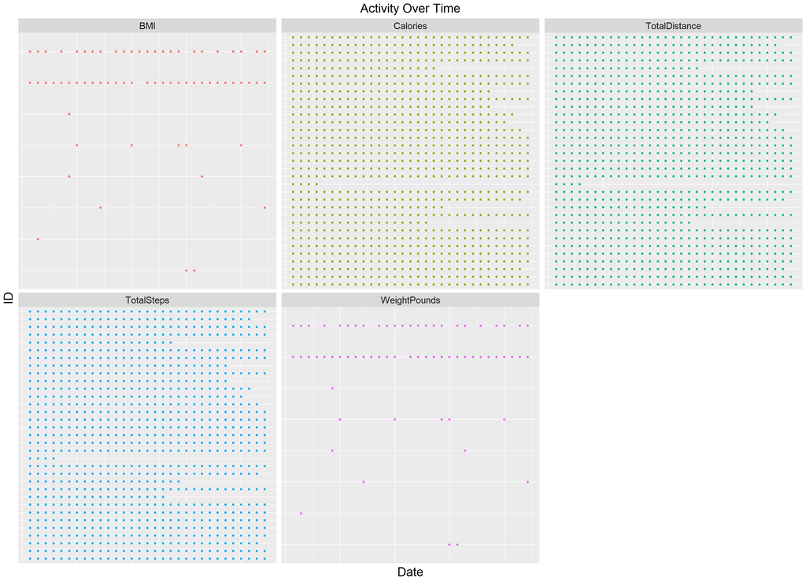

```r
ggplot(daily_long, aes(x = Date, y = Id)) +
  geom_point(aes(col = Variable)) +
  labs(title = "Activity Over Time", x = "Date", y = "ID") +
  facet_wrap(~Variable, scales = "free_y") +
  theme(plot.title = element_text(hjust = 0.5, size = 20),
        axis.title.y = element_text(size = 20),
        axis.title.x = element_text(size = 20),
        axis.text.x = element_blank(),
        axis.text.y = element_blank(),
        axis.ticks = element_blank(),
        legend.position = "none",
        strip.text = element_text(size = 15))
```

The plots reveal that only 2 individuals consistently tracked their weight. [BMI](https://www.nhs.uk/live-well/healthy-weight/bmi-calculator/#:~:text=The%20BMI%20calculation%20divides%20an,dividing%2070%20by%202.99%20%3D%2023.41) is calculated by dividing an adult’s weight in kilograms (kg) by their height in meters (m) squared. Weight plays a pivotal role in this calculation, which is why weight and BMI are interconnected. FitBit calculated BMI only for the recorded weight data. As for ‘TotalSteps,’ ‘Calories,’ and ‘TotalDistance,’ it appears that individuals who stopped tracking these metrics ceased their activity altogether. However, most of them displayed consistent tracking habits.

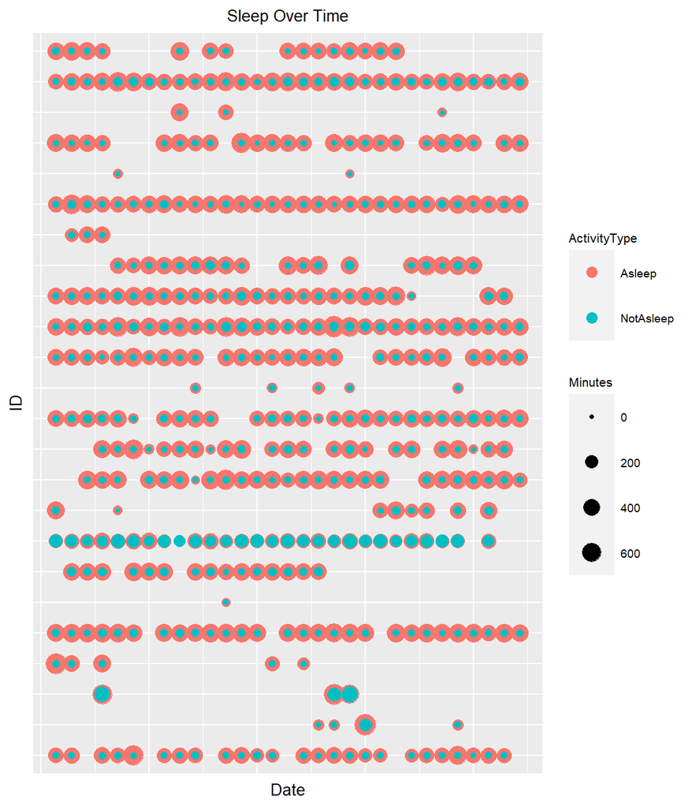

```r
ggplot(sleep_long, aes(x = Date, y = Id)) +
    geom_point(aes(col = ActivityType, size = Minutes)) +
    labs(title = "Sleep Over Time", x = "Date", y = "ID") +
    theme(plot.title = element_text(hjust = 0.5, size = 10),
          axis.text.x = element_blank(),
          axis.text.y = element_blank(),
          axis.ticks = element_blank(),
          axis.title.y = element_text(size = 10),
          axis.title.x = element_text(size = 10),
          legend.key.height = unit(1, 'cm'),
          legend.key.width = unit(1, 'cm'),
          legend.title = element_text(size = 8),
          legend.text = element_text(size = 7))  +
          guides(color = guide_legend(override.aes = list(size = 3)))
```

The ‘Sleep Over Time’ plot presents a distinct scenario. Only 3 individuals consistently recorded their sleep throughout the entire month. Among them, some tracked their sleep frequently, while others did so only occasionally throughout the entire period. Interestingly, it’s evident that people spend a significant amount of time in bed, not necessarily sleeping, and some get very little sleep. The intensity data was further analyzed using two different graphs.

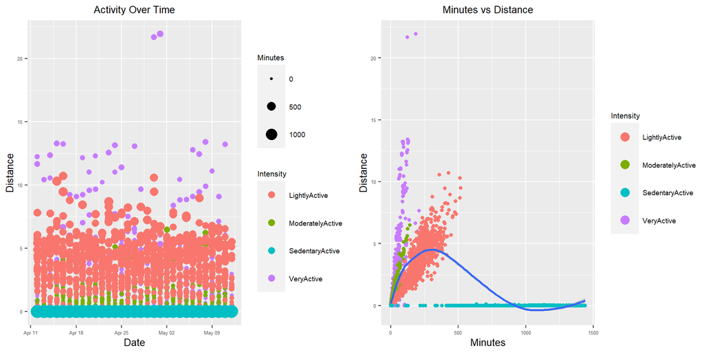

```r
intensities_plot1 <- ggplot(intensities_long, aes(x = Date, y = Distance)) +
  geom_point(aes(col = ActivityType, size = Minutes)) +
  labs(title = "Activity Over Time", col = "Intensity") +
  theme(plot.title = element_text(hjust = 0.5, size = 10),
        axis.text.x = element_text(size = 5),
        axis.text.y = element_text(size = 5),
        axis.title.y = element_text(size = 10),
        axis.title.x = element_text(size = 10),
        legend.key.height = unit(1, 'cm'),
        legend.key.width = unit(1, 'cm'),
        legend.title = element_text(size = 8),
        legend.text = element_text(size = 7))  +
        guides(color = guide_legend(override.aes = list(size = 3)))

intensities_plot2 <- ggplot(intensities_long, aes(x = Minutes, y = Distance)) +
  geom_point(aes(col = ActivityType)) +
  geom_smooth(method = "loess") +
  labs(title = "Minutes vs Distance", col = "Intensity") +
  theme(plot.title = element_text(hjust = 0.5, size = 10),
        axis.text.x = element_text(size = 5),
        axis.text.y = element_text(size = 5),
        axis.title.y = element_text(size = 10),
        axis.title.x = element_text(size = 10),
        legend.key.height = unit(1, 'cm'),
        legend.key.width = unit(1, 'cm'),
        legend.title = element_text(size = 8),
        legend.text = element_text(size = 7))  +
        guides(color = guide_legend(override.aes = list(size = 4)))


grid.arrange(intensities_plot1,intensities_plot2, ncol = 2)
```

At first glance, the plots reveal outliers in the ‘VeryActive’ data and indicate a correlation between distance and time for each intensity level. The intensities also demonstrate daily fluctuations, which warrant deeper investigation. To explore potential correlations within the data, a correlogram was made.

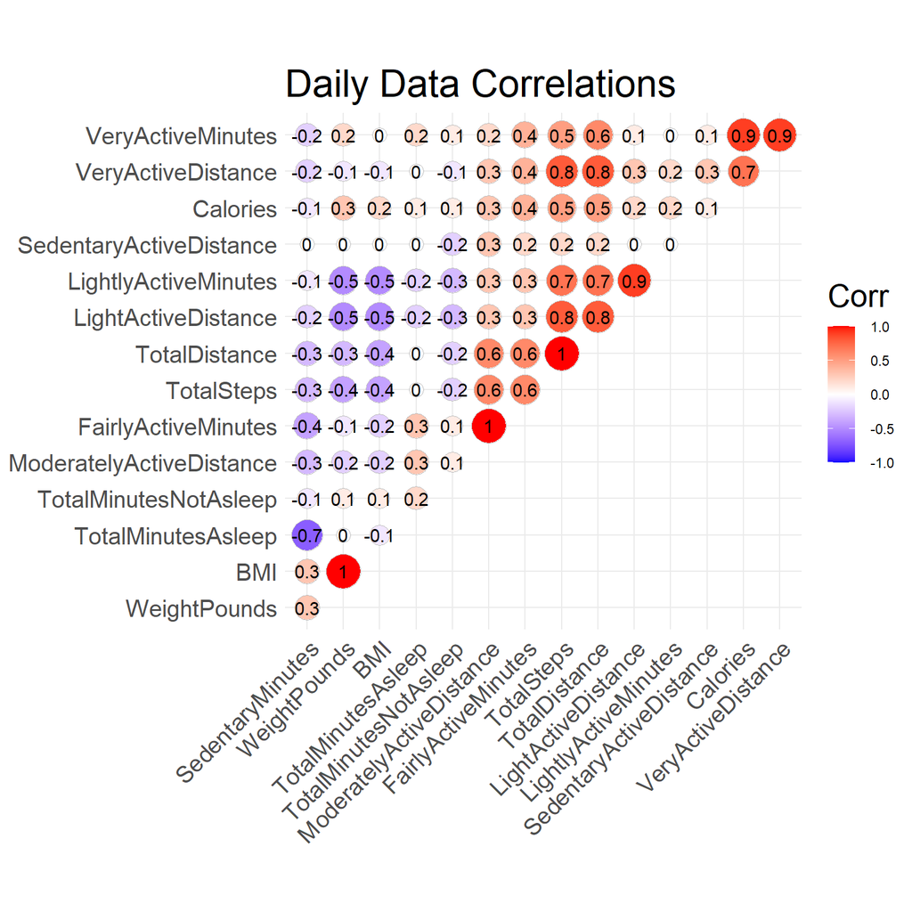

```r
daily_corr <- round(cor(daily[, 4:18], use = "na.or.complete"), 1)

ggcorrplot(
  daily_corr,
  hc.order = TRUE,
  type = "upper",
  method = "circle",
  title = "Daily Data Correlations",
  lab = TRUE,
  lab_size = 4,
) +
theme(title = element_text(size = 20),
      axis.text.x = element_text(size = 15),
      axis.text.y = element_text(size = 15))
```

As expected, minutes and distance intensities are positively correlated. For example, the more someone exercises lightly, the greater the distance they cover. Interestingly, the correlogram reveals a negative correlation between ‘TotalMinutesAsleep’ and ‘SedentaryMinutes’. A new plot was created to explore this phenomenon.

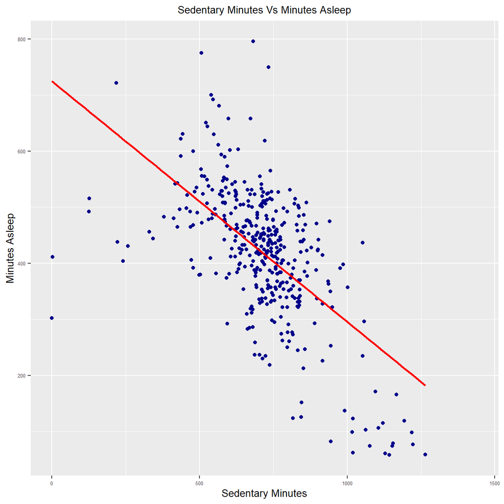

```r
ggplot(daily, aes(x = SedentaryMinutes, y = TotalMinutesAsleep)) +
  geom_point(col = "darkblue") +
  geom_smooth(method = "lm", se = FALSE, col = "red") +
  labs(title="Sedentary Minutes Vs Minutes Asleep",
       x = "Sedentary Minutes", y = "Minutes Asleep") +
  theme(plot.title = element_text(hjust = 0.5, size = 10),
        axis.text.x = element_text(size = 5),
        axis.text.y = element_text(size = 5),
        axis.title.y = element_text(size = 10),
        axis.title.x = element_text(size = 10))
```

Higher sedentary minutes might indicate a less active lifestyle, which could potentially affect sleep patterns. Individuals with more sedentary behavior might find it harder to fall asleep or maintain a deep sleep, leading to a reduction in total time asleep.

### Health data

To analyze the data, additional information about steps, calories, BMI, and sleep is required to compare the data to population standards. Firstly, let’s consider steps recommendations for adults. According to [research](https://www.ncbi.nlm.nih.gov/pmc/articles/PMC3197470/) conducted worldwide, scientists have concluded:

> In summary, research suggests that healthy adults typically take between 4,000 and 18,000 steps per day, with 10,000 steps being a reasonable target for health. Studies show a strong relationship between step cadence (64-170 steps/minute) and exercise intensity. A minimum of 100 steps/minute (equivalent to 3,000 steps in 30 minutes) represents moderate intensity walking. To meet physical activity guidelines, steps should be taken above habitual activities, in bouts of at least 10 minutes. Recommended daily steps with moderate intensity activity range from 7,000 to 11,000 steps, with a threshold of 7,000-8,000 steps associated with current health guidelines.

The calorie data is what FitBit calculated to be the users calorie expenditure. This calculation is detailed on [fitabase](https://www.fitabase.com/media/1930/fitabasedatadictionary102320.pdf)

> Fitbit uses the gender, age, height, and weight data entered into the user profile to calculate basal metabolic rate (BMR). The estimated energy expenditure that Fitbit provides takes into account the user’s BMR, the activity recorded by the device, and any manually logged activities. The provided data includes calorie expenditure but lacks user profiles or BMI information.

However, general average calorie expenditure ranges can be found for each gender on [Healthline](https://www.healthline.com/health/fitness-exercise/how-many-calories-do-i-burn-a-day#how-to-calculate):

> Most female adults need 1,600–2,200 calories per day, while adult males need 2,200–3,000 calories per day. However, the amount of calories you need each day is unique to your body and activity levels. If you’re looking to maintain your weight, you’ll want to ensure your calorie intake matches your calorie expenditure.

To calculate the ideal weight for each gender, we need the average heights for each group. Referencing the [Wikipedia Data](https://en.wikipedia.org/wiki/Average_human_height_by_country), the minimum and maximum average heights for women range from 148.1 cm to 171.8 cm, and for men, it ranges from 158.7 cm to 185.6 cm. [According to the World Health Organization:](https://www.who.int/europe/news-room/fact-sheets/item/a-healthy-lifestyle---who-recommendations)

> BMI (formerly called the Quetelet index) is a measure for indicating nutritional status in adults. It is defined as a person’s weight in kilograms divided by the square of the person’s height in metres (kg/m2). For example, an adult who weighs 70 kg and whose height is 1.75 m will have a BMI of 22.9. * Below 18.5 - Underweight * 18.5 – 24.9 - Normal weight * 25.0 – 29.9 - Pre-obesity * 30 and above - Obesity

Ideal weight was calculated based on a BMI range of 18.5 to 24.9, which falls under the category of ‘Normal Weight’ and an average height. For females, the ideal weight range is from 40.6 kg to 73.5 kg, and for males, it is from 46.6 kg to 85.8 kg.

[National sleep foundation](https://www.thensf.org/how-many-hours-of-sleep-do-you-really-need/) offers current research indicating that the ideal amount of sleep needed for adults is 7 to 9 hours. To make the above data accessible, a table was created.

| Steps | Calories | Weight.kg. | BMI | Sleep |
| --- | --- | --- | --- | --- |
| Low: 4k | Women: 1,600–2,200 | Women: 40.6 to 73.5 kg | Underweight: < 18.5 | 7-9 hours |
| Recommended: 10k | Men 2,200–3,000 | Men: 46.6 to 85.8 kg | Normal: 18.5–24.9 |  |
|  |  |  | Overweight: 25.0–29.9 |  |
|  |  |  | Obese: > 30 |  |

### Averages by ID

The next step involves comparing averages in the data for each user. To accomplish this, the ‘daily’ data was grouped by ID, and for sleep and intensity data, the grouping was done by ID and activity type. Subsequently, the mean of each variable was calculated.

```r
daily_averages <- daily %>%
  group_by(Id) %>%
  summarise(TotalSteps = round(mean(TotalSteps, na.rm = TRUE), 1),
            TotalDistance = round(mean(TotalDistance, na.rm = TRUE), 1),
            Calories = round(mean(Calories, na.rm = TRUE), 1),
            WeightKilos = round(mean(WeightPounds/2.20462, na.rm = TRUE), 1),
            BMI = round(mean(BMI, na.rm = TRUE), 1))
head(daily_averages)
```

```
## # A tibble: 6 × 6
##   Id         TotalSteps TotalDistance Calories WeightKilos   BMI
##   <chr>           <dbl>         <dbl>    <dbl>       <dbl> <dbl>
## 1 1503960366     12117.           7.8    1816.        52.6  22.6
## 2 1624580081      5744.           3.9    1483.       NaN   NaN
## 3 1644430081      7283            5.3    2811.       NaN   NaN
## 4 1844505072      2580.           1.7    1574.       NaN   NaN
## 5 1927972279       916.           0.6    2173.       134.   47.5
## 6 2022484408     11371.           8.1    2510        NaN   NaN
```

```r
sleep_averages <- sleep_long %>%
  group_by(Id, ActivityType) %>%
  summarise(Activity = round(mean(Minutes/60), 1));
head(sleep_averages)
```

```
## # A tibble: 6 × 3
## # Groups:   Id [3]
##   Id         ActivityType Activity
##   <chr>      <chr>           <dbl>
## 1 1503960366 Asleep            6
## 2 1503960366 NotAsleep         0.4
## 3 1644430081 Asleep            4.9
## 4 1644430081 NotAsleep         0.9
## 5 1844505072 Asleep           10.9
## 6 1844505072 NotAsleep         5.2
```

```r
intensities_averages <- intensities_long %>%
  group_by(Id, ActivityType) %>%
  summarise(Distance = round(mean(Distance), 1),
            Hours = round(mean(Minutes/60), 1));
head(intensities_averages)
```

```
## # A tibble: 6 × 4
## # Groups:   Id [2]
##   Id         ActivityType     Distance Hours
##   <chr>      <chr>               <dbl> <dbl>
## 1 1503960366 LightlyActive         4.2   3.7
## 2 1503960366 ModeratelyActive      0.8   0.3
## 3 1503960366 SedentaryActive       0    14.1
## 4 1503960366 VeryActive            2.9   0.6
## 5 1624580081 LightlyActive         2.6   2.6
## 6 1624580081 ModeratelyActive      0.4   0.1
```

```r
activity_averages <- activity_long %>%
  group_by(Id, ActivityType) %>%
  summarise(Hours = round(mean(Minutes/60), 1));
head(activity_averages)
```

```
## # A tibble: 6 × 3
## # Groups:   Id [1]
##   Id         ActivityType     Hours
##   <chr>      <chr>            <dbl>
## 1 1503960366 Asleep             6
## 2 1503960366 LightlyActive      3.7
## 3 1503960366 ModeratelyActive   0.3
## 4 1503960366 NotAsleep          0.4
## 5 1503960366 SedentaryActive   14.1
## 6 1503960366 VeryActive         0.6
```

All variables were then visualized in separate bar graphs. Please refer to the code for detailed notes on how the graphs were created.

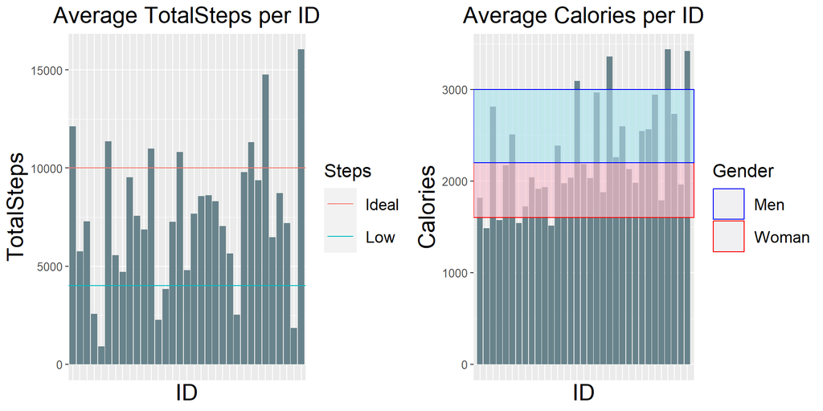

```r
steps_plot <- ggplot(daily_averages, aes(x = Id, y = TotalSteps)) +
  geom_col(fill = "lightblue4") +
  geom_hline(aes(yintercept = 4000, col = "Low")) +
  geom_hline(aes(yintercept = 10000, col = "Ideal")) +
  labs(title = "Average TotalSteps per ID", x = "ID", y = "TotalSteps", col = "Steps") +
  guides(x = "none") +
  theme(plot.title = element_text(hjust = 0.5, size = 20),
        axis.text.y = element_text(size = 10),
        axis.title.y = element_text(size = 20),
        axis.title.x = element_text(size = 20),
        legend.key.height = unit(1, 'cm'),
        legend.key.width = unit(1, 'cm'),
        legend.title = element_text(size = 16),
        legend.text = element_text(size = 14))  +
        guides(color = guide_legend(override.aes = list(size = 5)))


calories_plot <- ggplot(daily_averages) +
  geom_col(aes(x = Id, y = Calories), fill = "lightblue4") +
  geom_rect(aes(xmin = 0, xmax = length(Id) + 1, ymin = 1600, ymax = 2200,
                col = "Woman"), fill = "pink", alpha = 0.03) +
  geom_rect(aes(xmin = 0, xmax = length(Id) + 1, ymin = 2200, ymax = 3000,
                col = "Men"), fill = "lightblue", alpha = 0.03) +
  guides(x = "none") +
  labs(title = "Average Calories per ID", x = "ID", y = "Calories", col = "Gender") +
  scale_color_manual(values = c(Woman = "red", Men = "blue")) +
  theme(plot.title = element_text(hjust = 0.5, size = 20),
        axis.text.y = element_text(size = 10),
        axis.title.y = element_text(size = 20),
        axis.title.x = element_text(size = 20),
        legend.key.height = unit(1, 'cm'),
        legend.key.width = unit(1, 'cm'),
        legend.title = element_text(size = 16),
        legend.text = element_text(size = 14))  +
        guides(color = guide_legend(override.aes = list(size = 5)))

grid.arrange(steps_plot, calories_plot, ncol = 2)
```

Average ‘TotalSteps per ID’ plot clearly shows that the averages vary significantly. Most people average at least a minimum of 4000 steps per day. Although the majority of people meet the minimum daily step requirement, there is still considerable room for improvement to reach the recommended ideal step count of 10000 steps per day.

Based on the “Average Calories per ID” graph, most of the users are within the recommended calorie range, with a couple of users falling below and above the recommended range. After comparing the charts side by side, it’s evident that more steps don’t necessarily result in higher calorie expenditure. This finding aligns with insights from the corellogram, which indicates a moderate correlation of 0.5 between Steps and Calories. FitBit doesn’t provide data indicating which ID corresponds to which gender, making the analysis much shallower than necessary. We can only assume that IDs falling within the Women’s calorie range belong to women and those within the Men’s calorie range belong to men, but we can’t be certain. This limitation significantly impacts the depth of the analysis.

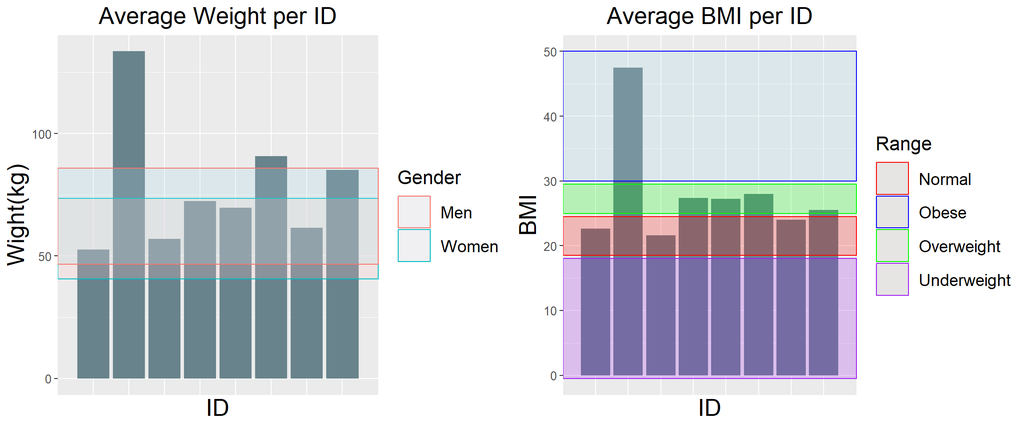

```r
weight_plot <- ggplot(daily_averages[complete.cases(daily_averages$WeightKilos),]) +
  geom_col(aes(x = Id, y = WeightKilos), fill = "lightblue4") +
  geom_rect(aes(xmin = 0, xmax = length(Id) +1, ymin = 40.6, ymax = 73.5, col = "Women"),
            fill = "pink", alpha = 0.03) +
  geom_rect(aes(xmin = 0, xmax = length(Id) +1, ymin = 46.6, ymax = 85.8, col = "Men"),
            fill = "lightblue", alpha = 0.03) +
  guides(x = "none") +
  labs(title = "Average Weight per ID", x = "ID", y = "Wight(kg)", col = "Gender") +
  theme(plot.title = element_text(hjust = 0.5, size = 20),
        axis.text.y = element_text(size = 10),
        axis.title.y = element_text(size = 20),
        axis.title.x = element_text(size = 20),
        legend.key.height = unit(1, 'cm'),
        legend.key.width = unit(1, 'cm'),
        legend.title = element_text(size = 16),
        legend.text = element_text(size = 14))  +
  guides(color = guide_legend(override.aes = list(size = 5)))

bmi_plot <- ggplot(daily_averages[complete.cases(daily_averages$BMI),]) +
  geom_col(aes(x = Id, y = BMI), fill = "lightblue4") +
  geom_rect(aes(xmin = 0, xmax = length(Id) + 1, ymin = -0.5, ymax = 18,
                col = "Underweight"), alpha = 0.03, fill = "purple") +
  geom_rect(aes(xmin = 0, xmax = length(Id) + 1, ymin = 18.5, ymax = 24.5,
                col = "Normal"), alpha = 0.03, fill = "red") +
  geom_rect(aes(xmin = 0, xmax = length(Id) + 1, ymin = 25, ymax = 29.5,
                col = "Overweight"), alpha = 0.03, fill = "green") +
  geom_rect(aes(xmin = 0, xmax = length(Id) + 1, ymin = 30, ymax = 50,
                col = "Obese"), alpha = 0.03, fill = "lightblue") +
  labs(title = "Average BMI per ID", x = "ID", y = "BMI", col = "Range") +
  guides(x = "none") +
  scale_color_manual(values = c(Underweight = "purple", Normal = "red",
                                Overweight = "green", Obese = "blue")) +
  theme(plot.title = element_text(hjust = 0.5, size = 20),
        axis.text.y = element_text(size = 10),
        axis.title.y = element_text(size = 20),
        axis.title.x = element_text(size = 20),
        legend.key.height = unit(1, 'cm'),
        legend.key.width = unit(1, 'cm'),
        legend.title = element_text(size = 16),
        legend.text = element_text(size = 14))  +
   guides(color = guide_legend(override.aes = list(size = 5)))

grid.arrange(weight_plot, bmi_plot, ncol = 2)
```

##### **Average Weight per ID**

Without gender-specific data, we are unable to delve into the details. However, it is evident that most people fall within the recommended weight range. There are two users who exceed these ranges, classifying them as slightly or very obese. Generally, the majority of users maintain a healthy weight.

##### **Average BMI per ID**

When considering BMI, gender-specific data is not necessary to determine the users’ health status. The majority of users have a healthy BMI or are slightly overweight, with only one user classified as obese.

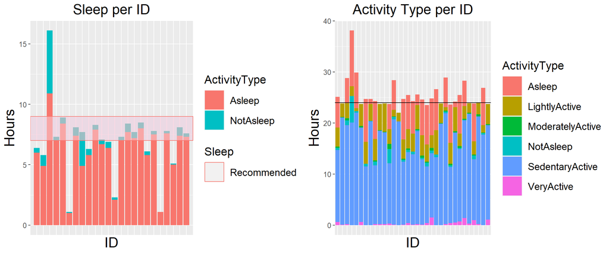

```r
sleep_plot <- ggplot(sleep_averages) +
  geom_col(aes(x = Id, y = Activity, fill = ActivityType),
           position = position_stack(reverse = TRUE)) +
  geom_rect(aes(xmin = 0, xmax = length(Id)/2 + 1, ymin = 7, ymax = 9,
                col = "Recommended"), fill = "pink", alpha = 0.02) +
  labs(title = "Sleep per ID", x = "ID", y = "Hours", col = "Sleep") +
  guides(x = "none") +
  theme(plot.title = element_text(hjust = 0.5, size = 20),
        axis.text.y = element_text(size = 10),
        axis.title.y = element_text(size = 20),
        axis.title.x = element_text(size = 20),
        legend.key.height = unit(1, 'cm'),
        legend.key.width = unit(1, 'cm'),
        legend.title = element_text(size = 16),
        legend.text = element_text(size = 14))  +
   guides(color = guide_legend(override.aes = list(size = 5)))

activity_plot <- ggplot(activity_averages) +
  geom_col(aes(x = Id, y = Hours, fill = ActivityType)) +
  labs(title = "Activity Type per ID", x = "ID", y = "Hours") +
  geom_hline(aes(yintercept = 24)) +
  guides(x = "none") +
  theme(plot.title = element_text(hjust = 0.5, size = 20),
        axis.text.y = element_text(size = 10),
        axis.title.y = element_text(size = 20),
        axis.title.x = element_text(size = 20),
        legend.key.height = unit(1, 'cm'),
        legend.key.width = unit(1, 'cm'),
        legend.title = element_text(size = 16),
        legend.text = element_text(size = 14))  +
   guides(color = guide_legend(override.aes = list(size = 5)))

grid.arrange(sleep_plot, activity_plot, ncol = 2)
```

##### **Sleep per ID**

Most people fall within the recommended sleep range of 7 to 9 hours, although one person consistently spends an extended period in bed. Additionally, three individuals have unusually low sleep durations, possibly indicating issues with the accuracy of sleep data collection.

##### **Activity per ID**

This chart was done to showcase activity type across the day per ID. The data most likely overlap because some individuals have over 24h of activity which is impossible. I’m assuming that sleep data isn’t accurate and because of that intensity graph was generated.

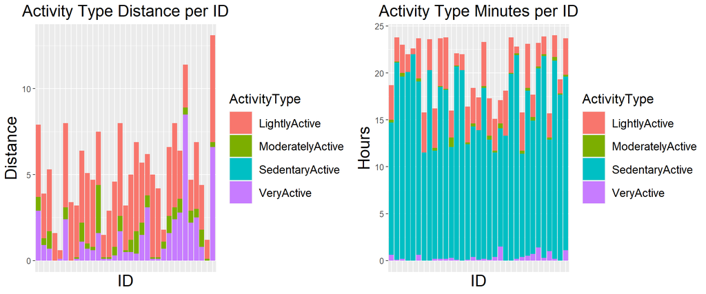

```r
int_plot_distance <- ggplot(intensities_averages) +
  geom_col(aes(x = Id, y = Distance, fill = ActivityType)) +
  labs(title = "Activity Type Distance per ID", x = "ID", y = "Distance") +
  guides(x = "none") +
  theme(plot.title = element_text(hjust = 0.5, size = 20),
        axis.text.y = element_text(size = 10),
        axis.title.y = element_text(size = 20),
        axis.title.x = element_text(size = 20),
        legend.key.height = unit(1, 'cm'),
        legend.key.width = unit(1, 'cm'),
        legend.title = element_text(size = 16),
        legend.text = element_text(size = 14))  +
   guides(color = guide_legend(override.aes = list(size = 5)))


int_plot_hours <- ggplot(intensities_averages) +
  geom_col(aes(x = Id, y = Hours, fill = ActivityType)) +
  labs(title = "Activity Type Minutes per ID", x = "ID", y = "Hours") +
  guides(x = "none") +
  theme(plot.title = element_text(hjust = 0.5, size = 20),
        axis.text.y = element_text(size = 10),
        axis.title.y = element_text(size = 20),
        axis.title.x = element_text(size = 20),
        legend.key.height = unit(1, 'cm'),
        legend.key.width = unit(1, 'cm'),
        legend.title = element_text(size = 16),
        legend.text = element_text(size = 14))  +
   guides(color = guide_legend(override.aes = list(size = 5)))

grid.arrange(int_plot_distance, int_plot_hours, ncol = 2)
```

Based on the charts, when users were in the sedentary active zone, as expected, they haven’t covered much distance. The majority of users spend at least 10 hours in the sedentary active category. Additionally, most users are active in every zone, with the lightly active zone being the most common. A new chart was created to illustrate the relationship between distance and minutes spent in each activity type.

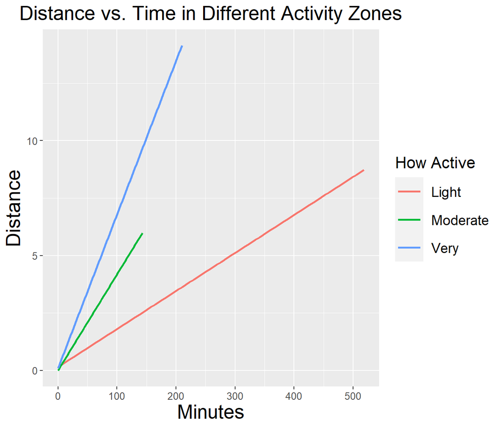

```r
light_data <- intensities_long %>%
  filter(ActivityType == "LightlyActive")
moderate_data <- intensities_long %>%
  filter(ActivityType == "ModeratelyActive")
very_data <- intensities_long %>%
  filter(ActivityType == "VeryActive")


ggplot() +
  geom_smooth(data = light_data, aes(x = Minutes, y = Distance, color = "Light"),
              se = FALSE, method = "lm") +
  geom_smooth(data = moderate_data, aes(x = Minutes, y = Distance, color = "Moderate"),
              se = FALSE, method = "lm") +
  geom_smooth(data = very_data, aes(x = Minutes, y = Distance, color = "Very"),
              se = FALSE, method = "lm") +
  labs(title = "Distance vs. Time in Different Activity Zones", color = "How Active") +
  theme(plot.title = element_text(hjust = 0.5, size = 20),
        axis.text.x = element_text(size = 10),
        axis.text.y = element_text(size = 10),
        axis.title.y = element_text(size = 20),
        axis.title.x = element_text(size = 20),
        legend.key.height = unit(1, 'cm'),
        legend.key.width = unit(1, 'cm'),
        legend.title = element_text(size = 16),
        legend.text = element_text(size = 14))  +
   guides(color = guide_legend(override.aes = list(size = 5)))
```

The chart clearly illustrates the difference in how quickly distance is gained in each intensity zone, with the light intensity showing the slowest progress and the very active zone exhibiting the fastest pace.

### Averages by day of week

The next step of the analysis was to look at the daily tracking averages for each day of the week to see if there’s any trends in tracking. Distance and calories are based on step count tracking and BMI is based on weight tracking, so these variables will be ignored for this part of the analysis.

```r
daily_wday_avg <- daily %>%
  group_by(Weekday) %>%
  summarise(TotalSteps = round(mean(TotalSteps, na.rm = TRUE), 1),
            HoursAsleep = round(mean(TotalMinutesAsleep, na.rm = TRUE)/60, 1),
            HoursNotAsleep = round(mean(TotalMinutesNotAsleep, na.rm = TRUE)/60, 1),
            Weight = round(mean(WeightPounds, na.rm = TRUE)/2.205, 1))
daily_wday_avg
```

```
## # A tibble: 7 × 5
##   Weekday   TotalSteps HoursAsleep HoursNotAsleep Weight
##   <ord>          <dbl>       <dbl>          <dbl>  <dbl>
## 1 Monday         7781.         7              0.6   69.5
## 2 Tuesday        8125          6.7            0.6   71.2
## 3 Wednesday      7559.         7.2            0.6   78.2
## 4 Thursday       7406.         6.7            0.6   69
## 5 Friday         7448.         6.8            0.7   69.3
## 6 Saturday       8153          7              0.7   71.7
## 7 Sunday         6933.         7.5            0.8   73.5
```

```r
sleep_wday_avg <- sleep_long %>%
  group_by(Weekday, ActivityType) %>%
  summarise(Hours = round(mean(Minutes)/60, 1))

head(sleep_wday_avg)
```

```
## # A tibble: 6 × 3
## # Groups:   Weekday [3]
##   Weekday   ActivityType Hours
##   <ord>     <chr>        <dbl>
## 1 Monday    Asleep         7
## 2 Monday    NotAsleep      0.6
## 3 Tuesday   Asleep         6.7
## 4 Tuesday   NotAsleep      0.6
## 5 Wednesday Asleep         7.2
## 6 Wednesday NotAsleep      0.6
```

```r
intensities_wday_avg <- intensities_long %>%
  group_by(Weekday, ActivityType) %>%
  summarise(Distance = round(mean(Distance), 1),
            Hours = round(mean(Minutes), 1))

head(intensities_wday_avg)
```

```
## # A tibble: 6 × 4
## # Groups:   Weekday [2]
##   Weekday ActivityType     Distance  Hours
##   <ord>   <chr>               <dbl>  <dbl>
## 1 Monday  LightlyActive         3.4  192.
## 2 Monday  ModeratelyActive      0.6   14
## 3 Monday  SedentaryActive       0   1028.
## 4 Monday  VeryActive            1.5   23.1
## 5 Tuesday LightlyActive         3.5  197.
## 6 Tuesday ModeratelyActive      0.6   14.3
```

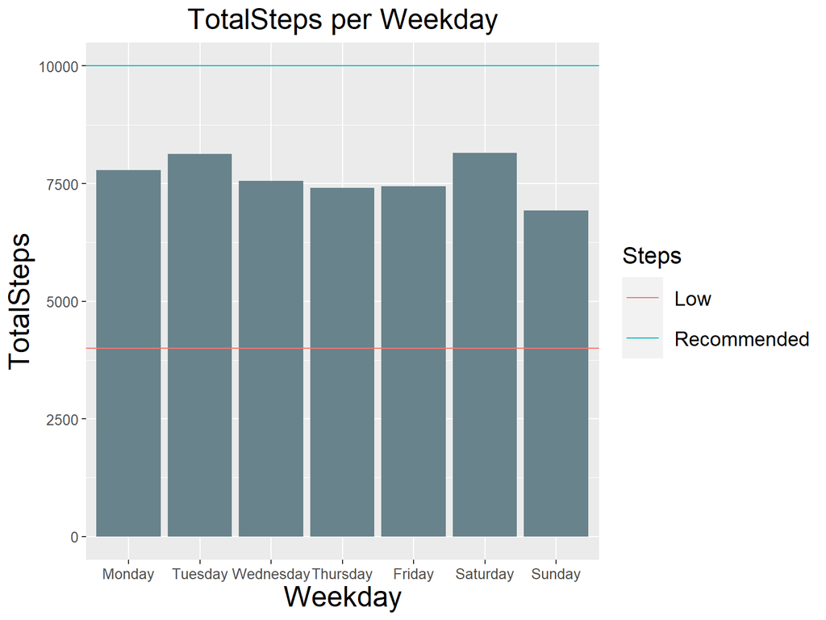

```r
ggplot(daily_wday_avg) +
  geom_col(aes(x = Weekday, y = TotalSteps), fill = "lightblue4") +
  geom_hline(aes(yintercept = 4000, col = "Low")) +
  geom_hline(aes(yintercept = 10000, col = "Recommended")) +
  labs(title = "TotalSteps per Weekday", col = "Steps") +
  theme(plot.title = element_text(hjust = 0.5, size = 20),
        axis.text.x = element_text(size = 10),
        axis.text.y = element_text(size = 10),
        axis.title.y = element_text(size = 20),
        axis.title.x = element_text(size = 20),
        legend.key.height = unit(1, 'cm'),
        legend.key.width = unit(1, 'cm'),
        legend.title = element_text(size = 16),
        legend.text = element_text(size = 14))  +
   guides(color = guide_legend(override.aes = list(size = 5)))
```

The step count doesn’t vary significantly from day to day, with Sunday recording the lowest count. On average, users take about 7500 steps, which falls 2500 steps below the recommended target.

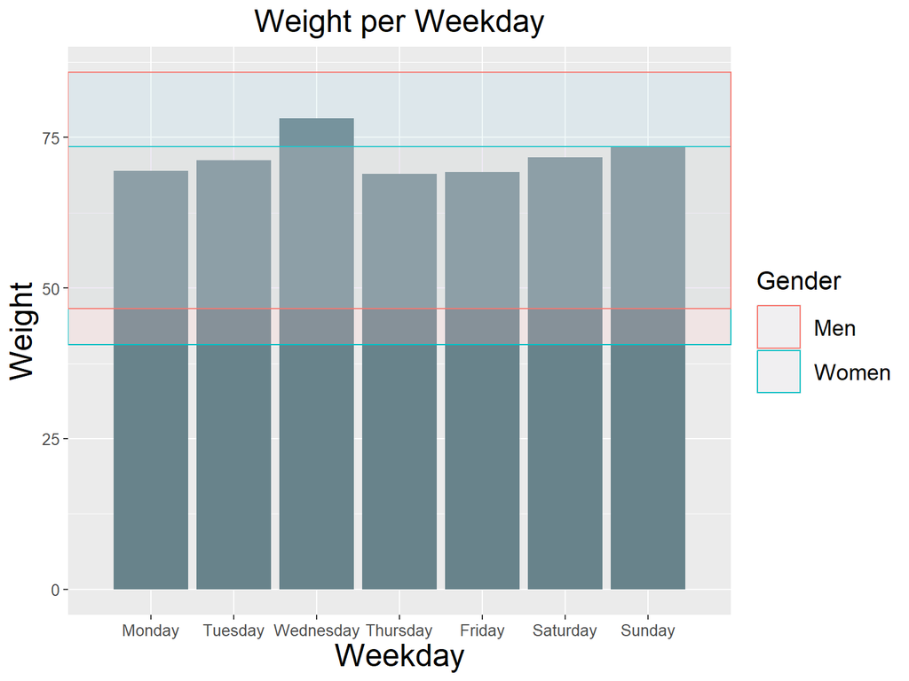

```r
ggplot(daily_wday_avg) +
  geom_col(aes(x = Weekday, y = Weight), fill = "lightblue4") +
  geom_rect(aes(xmin = 0, xmax = length(Weekday) +1, ymin = 40.6, ymax = 73.5, col = "Women"),
            fill = "pink", alpha = 0.03) +
  geom_rect(aes(xmin = 0, xmax = length(Weekday) +1, ymin = 46.6, ymax = 85.8, col = "Men"),
            fill = "lightblue", alpha = 0.03) +
  labs(title = "Weight per Weekday", col = "Gender") +
  theme(plot.title = element_text(hjust = 0.5, size = 20),
        axis.text.x = element_text(size = 10),
        axis.text.y = element_text(size = 10),
        axis.title.y = element_text(size = 20),
        axis.title.x = element_text(size = 20),
        legend.key.height = unit(1, 'cm'),
        legend.key.width = unit(1, 'cm'),
        legend.title = element_text(size = 16),
        legend.text = element_text(size = 14))  +
   guides(color = guide_legend(override.aes = list(size = 5)))
```

The averages fall within the weight ranges for both men and women, with Wednesday showing a slight increase due to the obese individual tracking their weight on that day. Generally, there isn’t much variation in weight throughout the week. As previously mentioned, the higher weight observed on Wednesday is likely attributed to the obese individual weighing themselves on that specific day.

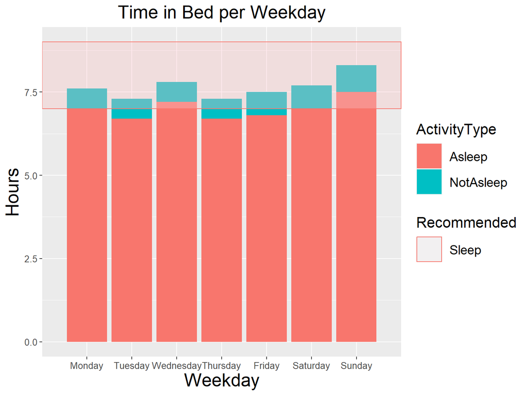

```r
ggplot(sleep_wday_avg) +
  geom_col(aes(x = Weekday, y = Hours, fill = ActivityType),
           position = position_stack(reverse = TRUE)) +
  geom_rect(aes(xmin = 0, xmax = length(Weekday)/2 + 1, ymin = 7, ymax = 9, col = "Sleep"),
            fill = "pink", alpha = 0.03) +
  labs(title = "Time in Bed per Weekday", col = "Recommended") +
  theme(plot.title = element_text(hjust = 0.5, size = 20),
        axis.text.x = element_text(size = 10),
        axis.text.y = element_text(size = 10),
        axis.title.y = element_text(size = 20),
        axis.title.x = element_text(size = 20),
        legend.key.height = unit(1, 'cm'),
        legend.key.width = unit(1, 'cm'),
        legend.title = element_text(size = 16),
        legend.text = element_text(size = 14))  +
  guides(color = guide_legend(override.aes = list(size = 5)))
```

Generally, people likely get enough sleep on average, although some sleep data appears to be unusually low. Sleep duration is shortest on Tuesday and Thursday, and longest on Sunday

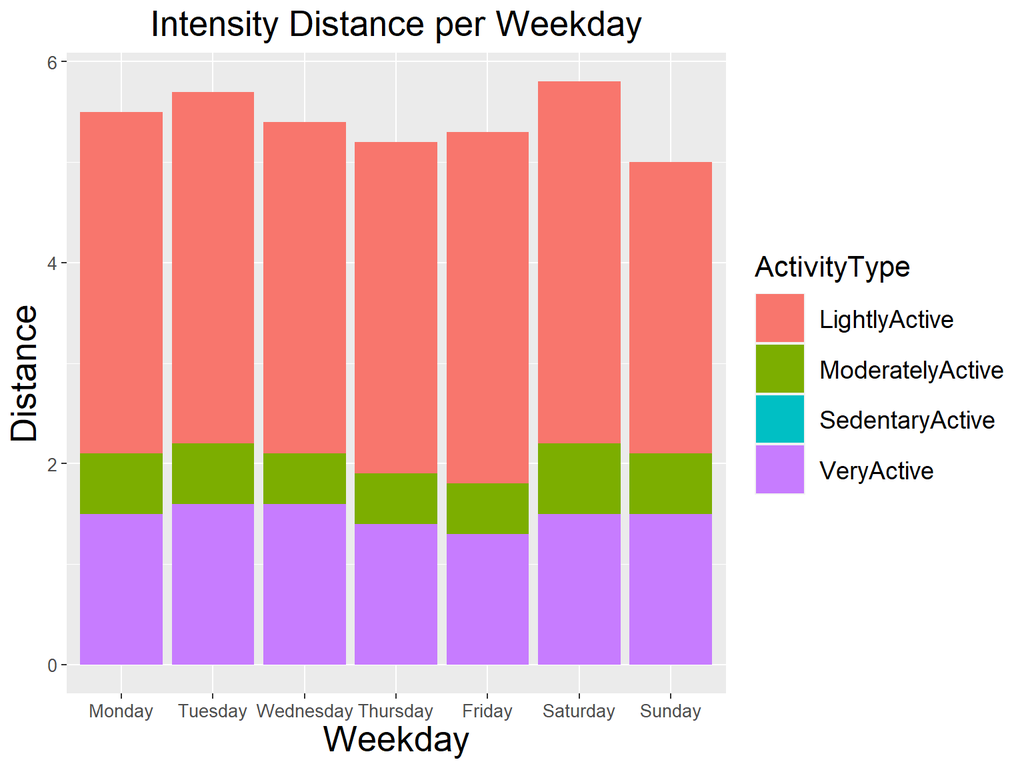

```r
ggplot(intensities_wday_avg) +
  geom_col(aes(x = Weekday, y = Distance, fill = ActivityType)) +
  labs(title = "Intensity Distance per Weekday") +
  theme(plot.title = element_text(hjust = 0.5, size = 20),
        axis.text.x = element_text(size = 10),
        axis.text.y = element_text(size = 10),
        axis.title.y = element_text(size = 20),
        axis.title.x = element_text(size = 20),
        legend.key.height = unit(1, 'cm'),
        legend.key.width = unit(1, 'cm'),
        legend.title = element_text(size = 16),
        legend.text = element_text(size = 14))  +
  guides(color = guide_legend(override.aes = list(size = 5)))
```

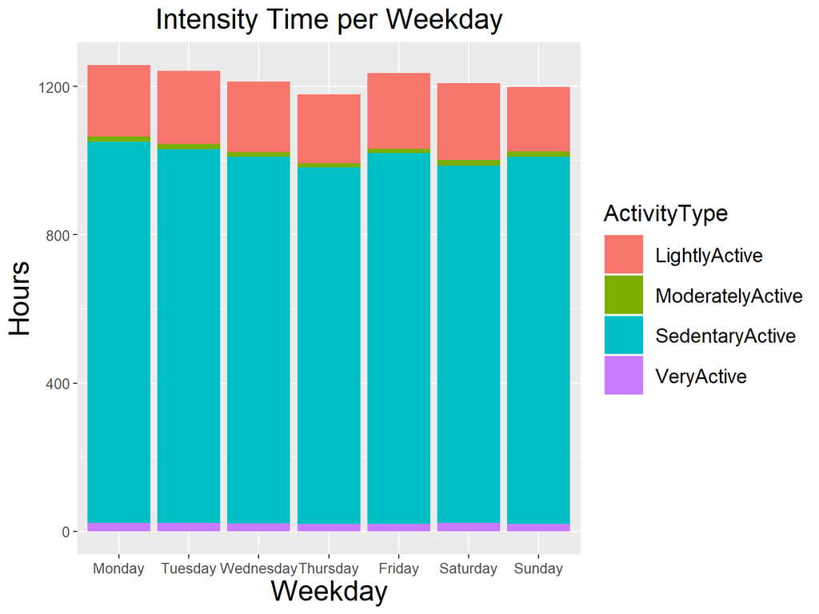

```r
ggplot(intensities_wday_avg) +
  geom_col(aes(x = Weekday, y = Hours, fill = ActivityType)) +
  labs(title = "Intensity Time per Weekday") +
  theme(plot.title = element_text(hjust = 0.5, size = 20),
        axis.text.x = element_text(size = 10),
        axis.text.y = element_text(size = 10),
        axis.title.y = element_text(size = 20),
        axis.title.x = element_text(size = 20),
        legend.key.height = unit(1, 'cm'),
        legend.key.width = unit(1, 'cm'),
        legend.title = element_text(size = 16),
        legend.text = element_text(size = 14))  +
  guides(color = guide_legend(override.aes = list(size = 5)))
```

This graph highlights even more clearly than the “ID” data that users spend the majority of their time being sedentary, averaging over 15 hours a day. Users then spend approximately 2-3 hours engaging in likely active activities and less than an hour in more intense activities.

# Summary and Marketing Recommendations

### Summary

The analysis show that every user has been tracking steps, with most of them on a regular basis,and that the step count didn’t vary much on a day to day basis. Most users haven’t met the recommended 10k steps per day, with 7.5k being the average. Fourth of the users were tracking their weight with only 2 doing it on a regular basis. According to BMI, all but one user are within recommended BMI range or slightly overweight. The data shows that some of the users quit tracking everything altogether during a month.

### Marketing Recommendations

The FitBit data has a limited sample size, encompassing both users and data measured over a short time span. It is highly discouraged to invest in high-effort marketing campaigns with large budgets based solely on this data. However, the analyzed data could provide valuable insights for BellaBeat to explore. Taking the above into consideration, easily testable and implementable solutions within the BellaBeat environment will be taken into account. This approach helps avoid the substantial costs associated with marketing campaigns. Given BellaBeat’s expertise as an IoT (Internet of Things) company, particularly in software development, it is well-equipped to implement software-based solutions effectively.

**1. Educational Content and Tips:**

- Create informative content within the Bellabeat app, addressing the importance of reaching 10k steps daily and providing tips on how to incorporate more steps into daily routines. Consider gamification elements within the app to encourage users to achieve their step goals.
- Educate users about the significance of weight tracking and offer incentives or rewards for regular weight tracking. Highlight success stories to motivate users who are reluctant to track their weight.

**2. Promote Active Lifestyles Outside of Workouts:**

- Leverage the intensity data to create challenges or achievements within the Bellabeat app. Encourage users to engage in short bursts of activity throughout the day, especially those working in office jobs, to bridge the gap between their lower step count and active lifestyle.

To make more impactful, data-driven marketing decisions, a larger sample size is crucial. A larger sample size provides a more representative and accurate reflection of the target audience. Small sample size can lead to skewed or unreliable results, making it difficult for data analysts to draw meaningful conclusions or make confident recommendiations based on the data, as demonstrated by our observations with sleep and weight data.

# Further analysis

**1. Sample size**

A larger sample size provides a clearer picture of the target audience and enables to draw more accurate conclusions. Previous experiences with sleep and weight data have highlighted the unreliability of results from small groups. Therefore, having a larger and diverse dataset is crucial for making well-informed decisions and recommendations based on the analysis.

**2. New market opportunity**

India’s wearable band market is flourishing, with significant triple-digit growth in Q1 2023. Local vendors like Fire Boltt, Noise, and boAt are driving this growth by offering value-for-money basic watches, meeting the rising demand. However, relying solely on entry-level hardware won’t ensure long-term success. Vendors need to evolve to meet changing consumer demands for enhanced features and integrated device experiences to create upgrade opportunities.

BellaBeat has an edge as IoT company that can bridge seemless basic watch with a tracking features. On top of that, BellaBeat already has infrastructure which is **BellaBeat App** and **Time**, a wellness watch blending classic aesthetics with smart technology. To gather first-hand data from the Indian market, BellaBeat could collaborate with local health and fitness experts, yoga instructors, nutritionists, and wellness influencers to introduce their products to the targeted audience.